# Regresión Lineal - Predicción de lluvia

### Victor Bucheli Guerrero y Daniel León

### Octubre de 2018

Cómo predecir usando una moneda?

La función *sample* permite generar aleatoriamente un entero. Podemos hacer el ejercicio con 0 y 1.

```r
x <- sample(0:1,1)
if ( x > 0 ){
  print("LLUEVE, VOY POR EL CARRO")
}else{print("NO LLUEVE, VEO LA FINAL!!")}
```

```
[1] "NO LLUEVE, VEO LA FINAL!!"
```

Podemos correr varias veces la función y sacar un promedio, y si supera un umbral decidir si vamos o no.

```r
x1 <- sample(0:1, 5, replace =T)
y1 <- 0
for(i in 1:5){
  y1<-y1+x1[i]
}
x1
```

```
[1] 0 0 0 1 0
```

```r
if (y1/5 > 0.5){
  print("LLUEVE, VOY POR EL CARRO")
}else{
  print("NO LLUEVE, VEO LA FINAL!!!")
}
```

```
[1] "NO LLUEVE, VEO LA FINAL!!!"
```

En las regresiones lineales:

La información es modelada para ajustarse a una función de la forma mx+b Usualmente usa el método del mínimo cuadrado para el ajuste. El modelo es usado para predecir.

Los valores continuos pertenecen a una variable, por ejemplo:

Tenemos las temperaturas mínimas, máximas, y la humedad a las 3pm, y la predicción de lluvia para el siguiente día. La regresión lineal sería usada para predecir la lluvia del siguiente día dado un conjunto de datos.

Para realizar la regresión del ejemplo anterior vamos a tomar como ejemplo el data set de temperatura que se encuentra en el archivo weather-mod.csv.

```r
#install.packages('e1071', dep = TRUE)
library(e1071)
tiempo.dataset = read.csv("weather-mod.csv")
```

## Análisis Gráfico

Para realizar nuestra regresión lineal correctamente, establecer una relación lineal estadísticamente significativa, tenemos que entender como están distribuidos nuestros datos.

Antes de continuar vamos a definir dos conceptos, - respuesta: es la variable que queremos predecir, en general Y. - predictor: variable que nos da la información para predecir, en general X.

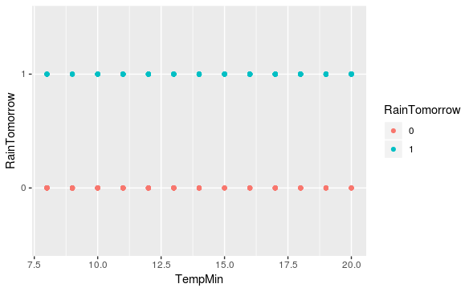

```r
#install.packages('ggplot2')
require(ggplot2)
aux1 <- tiempo.dataset
aux1[, "RainTomorrow"] <- as.factor(aux1[, "RainTomorrow"])
qplot(TempMin,RainTomorrow,data=aux1,colour=RainTomorrow)
```

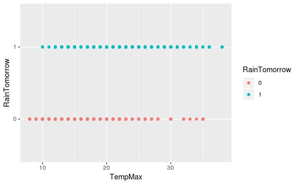

```r
qplot(TempMax,RainTomorrow,data=aux1,colour=RainTomorrow)
```

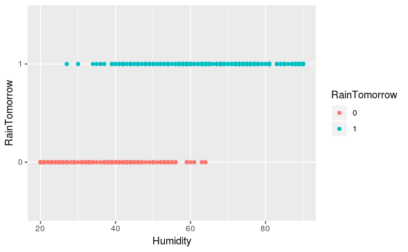

```r
qplot(Humidity,RainTomorrow,data=aux1,colour=RainTomorrow)
```

## Diagrama de cajas y bigotes

Mediante el diagrama de cajas y bigotes observamos los valores atípicos que pueden traer malos resultados.

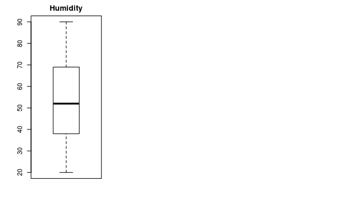

```r
par(mfrow=c(1, 3))#Obtenemos las tres gráficas  en el mismo cuadro de respuesta.
boxplot(tiempo.dataset[, "Humidity"], main="Humidity")  #Diagrama para "Humidity"
```

## Diagramas de densidad e histograma

El diagrama de densidad nos permite determinar si la distribución de cada una de las variables involucradas es normal.

```r
library(e1071)
par(mfrow=c(1, 3))#Obtenemos las dos gráficas  en el mismo cuadro de respuesta.
plot(density(tiempo.dataset[, "Humidity"]), main="Diagrama: Humidity", ylab="Frecuencia")
polygon(density(tiempo.dataset[, "Humidity"]), col="red")
```

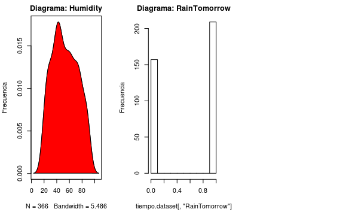

```r
hist(tiempo.dataset[, "RainTomorrow"], main="Diagrama: RainTomorrow" , ylab="Frecuencia") #Histograma
```

## Modelo

Podemos determinar la variable respuesta mediante la formula

#### Y=β1+β2*X+ϵ

Donde β1 es el intercepto, β2 es la pendiente, X es el valor conocido y ϵ es el término del error.

Tenemos que crear un modelo relacional y para eso vamos a utilizar la función lm.

```r
set.seed(1234) # semilla
muestra.cantidad <- floor(0.7 * nrow(tiempo.dataset))
entrenamiento.index <- sample(seq_len(nrow(tiempo.dataset)), size = muestra.cantidad)
conjunto_entrenamiento <- tiempo.dataset[entrenamiento.index, ]
conjunto_prueba <- tiempo.dataset[- entrenamiento.index, ]
modelo.lineal <- lm(RainTomorrow ~ Humidity, data = conjunto_entrenamiento) # Modelo regresión lineal
summary(modelo.lineal)
```

```
Call:
lm(formula = RainTomorrow ~ Humidity, data = conjunto_entrenamiento)

Residuals:
     Min       1Q   Median       3Q      Max
-0.78070 -0.22186 -0.01737  0.23751  0.83829

Coefficients:
             Estimate Std. Error t value Pr(>|t|)
(Intercept) -0.384459   0.060056  -6.402 7.37e-10 ***
Humidity     0.018206   0.001037  17.550  < 2e-16 ***
---
Signif. codes:  0 ‘***’ 0.001 ‘**’ 0.01 ‘*’ 0.05 ‘.’ 0.1 ‘ ’ 1

Residual standard error: 0.3299 on 254 degrees of freedom
Multiple R-squared:  0.548, Adjusted R-squared:  0.5463
F-statistic:   308 on 1 and 254 DF,  p-value: < 2.2e-16
```

Con esto tenemos el intercepto y el valor de la pendiente. Parece que ya podemos proceeder a realizar nuestra predicción de valores, pero aún no es posible, antes de utilizar un modelo lineal tenemos que determinar si este es estadísticamente significativo.

Realizando un resumen estadístico de el modelo lineal podemos determinar varias cosas:

- p-value: Podemos encontrar el p-value general en la última linea y el p-value para cada predictor en la segunda línea abajo de Coefficients. El valor p-value es sumamente importante, porque podemos considerar un modelo lineal estadísticamente significativo sólo cuando los valores p-value sean menor al nivel estadístico de significancia, idealmente 0.05. Podemos observar visualmente esto con las estrellas al final de la fila, mayor número de estrellas más significante es la variable.
- R-Squared: Lo que R-Squared nos dice es la variación que hay en la variable respuesta.

Para el R-Squared y R-Squared Ajustado, mientras el valor más grande mejor es la significancia de nuestro modelo, para R-Squared se recomienda que sea un valor mayor a 0.7.

## Grafico del modelo lineal

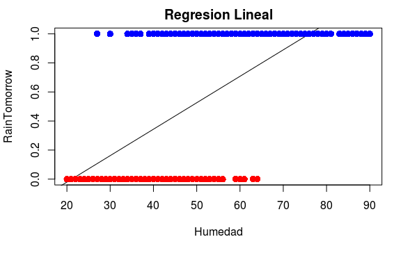

```r
colores <- ifelse(tiempo.dataset[, "RainTomorrow"] == 0, "red", "blue")
plot(tiempo.dataset[, "Humidity"], tiempo.dataset[, "RainTomorrow"], col = colores, main="Regresion Lineal" , abline(modelo.lineal), cex=1.3, pch=16, xlab = "Humedad", ylab = "RainTomorrow")
```

## Prediccion

Mediante la función predict podemos predecir un nuevo valor para la variable respuesta.

La función predict recibe como parametros el modelo y un vector con los datos a retornar.

```r
prediccion_lineal <-predict(modelo.lineal, conjunto_prueba, interval = "prediction")
prediccion_lineal
```

[output not shown]

[output not shown]